# Assignment 8

Luke Keirn

2024-04-04

#1. Read the data file unpopular_songs.csv using the read_csv() function in tidyverse and call this data frame songs.

```r
library(tidyverse)
songs <- read_csv("unpopular_songs_data.csv")
```

#2. Get a glimpse of the data and indicate the number of observations and the number of variables in the data.

```r
glimpse(songs)
```

```
## Rows: 10,877
## Columns: 17
## $ danceability     <dbl> 0.530, 0.565, 0.427, 0.421, 0.537, 0.710, 0.419, 0.56…
## $ energy           <dbl> 0.770, 0.730, 0.546, 0.531, 0.804, 0.621, 0.821, 0.62…
## $ key              <dbl> 4, 1, 4, 7, 8, 9, 11, 1, 0, 5, 2, 2, 0, 0, 5, 10, 11,…
## $ loudness         <dbl> -6.633, -6.063, -8.727, -5.516, -7.378, -7.879, -5.76…
## $ mode             <dbl> 0, 1, 1, 1, 0, 0, 0, 1, 1, 1, 0, 1, 1, 1, 1, 1, 0, 0,…
## $ speechiness      <dbl> 0.0389, 0.0730, 0.0849, 0.0262, 0.1570, 0.0329, 0.043…
## $ acousticness     <dbl> 0.28400, 0.36500, 0.53900, 0.70600, 0.37900, 0.40500,…
## $ instrumentalness <dbl> 0.501000, 0.000000, 0.015200, 0.000208, 0.000489, 0.0…
## $ liveness         <dbl> 0.7440, 0.2370, 0.3680, 0.1100, 0.3230, 0.1030, 0.127…
## $ valence          <dbl> 0.623, 0.511, 0.435, 0.383, 0.543, 0.546, 0.343, 0.65…
## $ tempo            <dbl> 120.144, 130.026, 78.345, 85.080, 139.950, 125.985, 8…
## $ duration_ms      <dbl> 225696, 158093, 167262, 236832, 239400, 194560, 19528…
## $ explicit         <lgl> FALSE, FALSE, FALSE, FALSE, FALSE, FALSE, FALSE, FALS…
## $ popularity       <dbl> 2, 2, 2, 2, 2, 2, 2, 2, 2, 2, 2, 2, 2, 13, 5, 14, 14,…
## $ track_name       <chr> "No Regrets", "Wild Life", "Fangs", "Afterburner", "H…
## $ track_artist     <chr> "James Reeder", "James Reeder", "James Reeder", "Jame…
## $ track_id         <chr> "6f2c4a9lNx8aowZJngv7cJ", "3fTs52jsDzSuVLsifxNKO8", "…
```

```r
num_observations <- nrow(songs)
print(num_observations)
```

```
## [1] 10877
```

```r
num_variables <- ncol(songs)
print(num_variables)
```

```
## [1] 17
```

#3. Find how many songs that have danceability higher than the median dancebility, energy lower than the median energy, loudness lower than the median loudness, speechiness higher than the medain speechiness, and the popularity is 1.

```r
library(dplyr)
median_danceability <- median(songs$danceability)
median_energy <- median(songs$energy)
median_loudness <- median(songs$loudness)
median_speechiness <- median(songs$speechiness)
num_songs_filtered <- songs %>%
  filter(danceability > median_danceability,
         energy < median_energy,
         loudness < median_loudness,
         speechiness > median_speechiness,
         popularity == 1) %>%
  nrow()
print(num_songs_filtered)
```

```
## [1] 288
```

#4. Sort the data frame songs by popularity, duration_ms via decending order, and key, and save the result back to the original data frame. Then only print the first 5 songs.

```r
songs <- songs %>%
  arrange(desc(popularity), desc(duration_ms), key)
head(songs, 5)
```

```
## # A tibble: 5 × 17
##   danceability energy   key loudness  mode speechiness acousticness
##          <dbl>  <dbl> <dbl>    <dbl> <dbl>       <dbl>        <dbl>
## 1        0.786  0.576     1    -6.97     1      0.306         0.101
## 2        0.788  0.793     5    -3.45     0      0.0599        0.12
## 3        0.825  0.767     1    -4.29     0      0.0543        0.152
## 4        0.709  0.388     1   -15.2      0      0.0472        0.205
## 5        0.556  0.403     2   -11.7      1      0.554         0.283
## # ℹ 10 more variables: instrumentalness <dbl>, liveness <dbl>, valence <dbl>,
## #   tempo <dbl>, duration_ms <dbl>, explicit <lgl>, popularity <dbl>,
## #   track_name <chr>, track_artist <chr>, track_id <chr>
```

#5. Change the data type of popularity to a factor in the data frame songs and create a boxplot of the distribution of duration_ms by popularity. Discuss the distribution of durations_ms by popularity.

When looking at the distribution of the durations_ms by popularity one may notice there are numerous outliers within the data. With this one might take into the consider the effect how accurate the data may be. Along with this one may also notice lots of similarities in popularity’s medians as they are all very similar, and have similar IQR’s.

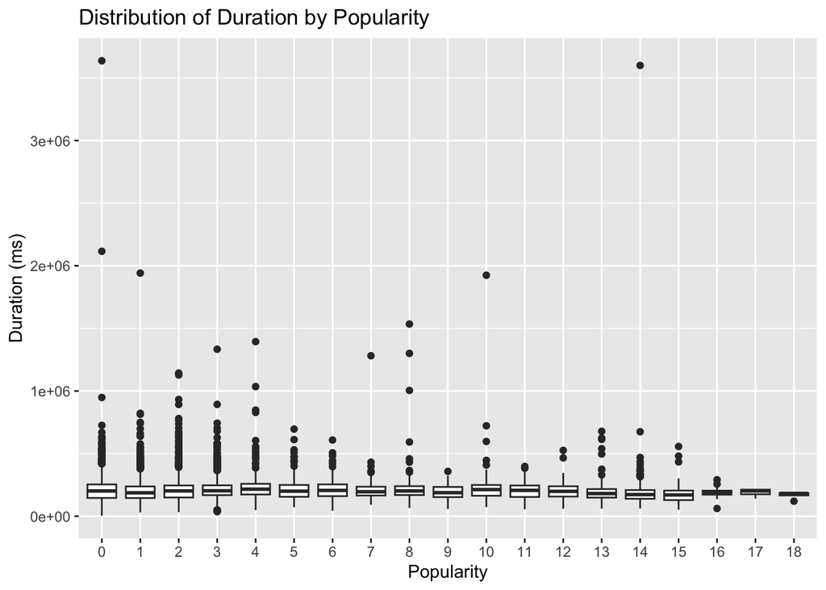

```r
library(ggplot2)
songs <- songs %>%
  mutate(popularity = as.factor(popularity))
ggplot(songs, aes(x = popularity, y = duration_ms)) +
  geom_boxplot() +
  labs(x = "Popularity", y = "Duration (ms)") +
  ggtitle("Distribution of Duration by Popularity")
```

#6. Create a boxplot of the distribution of instrumentalness by popularity. Discuss the distribution of instrumentalness by popularity.

When looking at the boxplot the data seems to be skewed left. This can be seen with the larger y values being found the more we move left on the x axis with popularities such as 1,2,3 and even 5. Much like previous visuals one may also notice the numerous amount fo outliers within the data set.

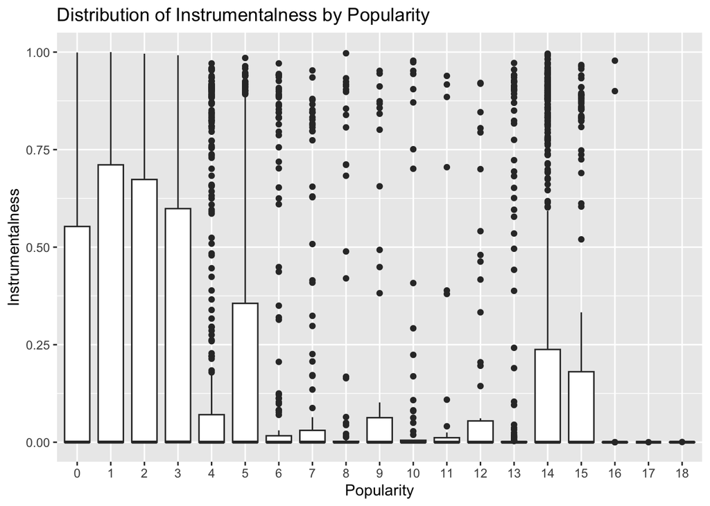

```r
ggplot(songs, aes(x = popularity, y = instrumentalness)) +
  geom_boxplot() +
  labs(x = "Popularity", y = "Instrumentalness") +
  ggtitle("Distribution of Instrumentalness by Popularity")
```

#7. What do you find based on the boxplots in Questions 4 and 5.

From the data above one might guess that the data provided is not the most relaible with the amount of outliers within the set. ALong with this one can exam the relationship between popularity and instrumentalness where lower values tend to have a higher probability.

#8. Create a histogram to show the distribution of instrumentalness and describe the distribution.

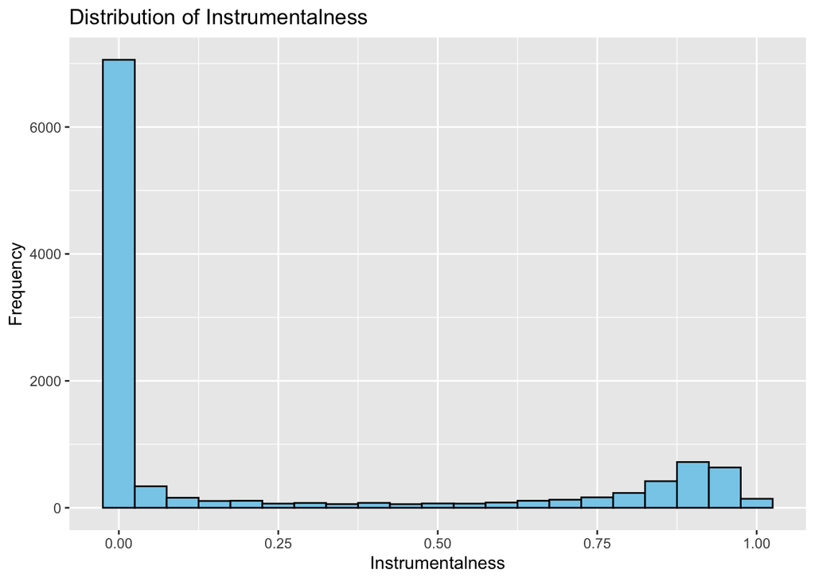

```r
ggplot(songs, aes(x = instrumentalness)) +
  geom_histogram(binwidth = 0.05, fill = "skyblue", color = "black") +
  labs(x = "Instrumentalness", y = "Frequency") +
  ggtitle("Distribution of Instrumentalness")
```

#9. Group the data frame songs by track_artist and find the correspond median, Q3 - Q1 for danceability, energy, speechiness, acousticness, instrumentalness, liveness, valence and counts for each track_artist. Save the result to unpopular_artists and sort the data frame via the descending order of counts. Print the top 10 unpopular artists and the corresponding information in unpopular_artists. Summarize your finding based on the result shown here